# Michael Adjemian

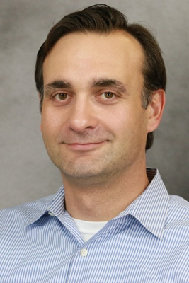

**Bio:** Michael K. Adjemian is a Professor in the Department of Agricultural and Applied Economics at the University of Georgia. Previously, he worked as a Senior Research Economist at the USDA Economic Research Service and as a Senior Economist at the White House Council of Economic Advisers. Mike received a Ph.D. in Agricultural and Resource Economics from the University of California at Davis in 2009. His research is focused on the economics of commodity markets, international trade, and U.S. agricultural policies. His research has been published in leading field journals, including the American Journal of Agricultural Economics, Applied Economic Perspectives and Policy, Food Policy, and the Journal of Commodity Markets. Mike is a Senior Fellow at the Rennes School of Business’ Center for Unframed Thinking, a consultant for the Commodity Futures Trading Commission and the State of Georgia’s Office of Planning and Budget, and serves on the board of directors for the Council on Food, Agricultural and Resource Economics (C-FARE). Since 2019, Mike has led and authored the university-wide annual UGA Economic Impact Report.

**Presentation Title:** Decomposing Food Price Inflation into Supply and Demand Shocks

**Abstract:** Recent food price inflation in the United States is comparable to historically sharp increases observed in the 1970s and early-1980s. Many factors are likely responsible, including supply chain backups and increased production costs brought on by the Covid-19 pandemic and its aftermath, weaker global markets for wheat and fertilizers following Russia’s invasion of Ukraine, and the strong aggregate demand driven in part by historically-large U.S. government stimulus efforts. Using a newly-developed technique to identify the contributions supply and demand shocks make to food price inflation over time, we find that while about 77 percent of the observed food category-level food price changes from the early-1990s up to the pandemic period were due to supply shocks (with the demand side taking up the remaining 23 percent), recent inflation is characterized by demand shocks to a far greater degree—about twice as much as in the past. We show how decompositions like these, particularly when accomplished using food price data from local markets, can help target inflation-reducing interventions. In addition, we exploit the national price data to identify important contributors to inflation from both sides of the market.